# posteriorHCA

[figure not shown]

`PosteriorHCA` applies **Bayesian inference** to model the comprehensive **Human Cell Atlas (HCA)**, allowing researchers to probabilistically analyze both **cellular composition** and **gene expression** patterns across human samples.

This package provides two main analytical capabilities:

1. **Cellular Composition Analysis**: Uses the `sccomp` package to model variations in cell type proportions across:
   - **Cell Types**
   - **Sex**
   - **Age**
   - **Ethnicity**
   - **Disease conditions**
   - **Tissue Groups**
2. **Gene Expression Prediction**: Uses `brms` models to predict gene expression levels for specific cell types and genes based on sample metadata including:
   - **Cell Types**
   - **Sex**
   - **Age Decade**
   - **Disease Groups**
   - **Ethnicity Groups**
   - **Assay Groups**
   - **Tissue Groups**

The probabilistic landscapes are **pre-trained**, meaning they represent **posterior distributions** estimated from millions of cells. `PosteriorHCA` makes these **queryable**, allowing researchers to:

- **Test hypotheses** against precomputed reference baselines.
- **Compare new samples** to expected cellular composition distributions.
- **Predict gene expression** levels for specific cell types and genes.
- **Assess how cell proportions and gene expression vary** across human conditions.

## **Installation**

To install the latest development version of `PosteriorHCA` from GitHub, run:

```r
# Install devtools if not already installed
install.packages("devtools")

# Install PosteriorHCA from GitHub
devtools::install_github("MangiolaLaboratory/posteriorHCA")
```

Once installed, load the package:

```r
library(posteriorHCA)
```

To rebuild this vignette **and** sync `README.md`, run `source("scripts/render_introduction.R"); render_introduction()` (or `Rscript scripts/render_introduction_cli.R` from the package root). Plain `rmarkdown::render("vignettes/Introduction.Rmd")` only builds the vignette HTML.

## Usage Examples

### **1. Cellular Composition Analysis**

#### Load relevant packages and example data

The package includes a small example dataset for demonstration:

```r
data(example_proportions)
print(example_proportions)
```

```
#> # A tibble: 26 × 3
#>    sample_id                        cell_type       proportion
#>    <chr>                            <chr>                <dbl>
#>  1 0000c153da22cf963b807c0563aca6a6 b memory          0
#>  2 0000c153da22cf963b807c0563aca6a6 b naive           0
#>  3 0000c153da22cf963b807c0563aca6a6 cd14 mono         0
#>  4 0000c153da22cf963b807c0563aca6a6 cd16 mono         0.00502
#>  5 0000c153da22cf963b807c0563aca6a6 cd4 fh em         0
#>  6 0000c153da22cf963b807c0563aca6a6 cd4 naive         0
#>  7 0000c153da22cf963b807c0563aca6a6 cd4 tcm           0.000359
#>  8 0000c153da22cf963b807c0563aca6a6 cd4 th1 em        0
#>  9 0000c153da22cf963b807c0563aca6a6 cd4 th1/th17 em   0.000359
#> 10 0000c153da22cf963b807c0563aca6a6 cd4 th17 em       0
#> # ℹ 16 more rows
```

#### Load the healthy sccomp reference

The default composition model is a healthy-only CellNexus sccomp fit. Unknown covariates can be left as `NA`; sccomp marginalises over them automatically.

```r
sccomp_fit <- load_sccomp_fit()
```

```
#> ℹ Using cached file: /home/a1237163/.cache/R/posteriorHCA/sccomp_est/cellNexus_1_0_12/estimates_age_decade___L3___disease_FALSE___immune_only_TRUE.rds
```

#### Draw healthy reference proportions

```r
comp_draws <- composition_draws(
  sccomp_fit,
  sex = "male",
  age_decade = "4",
  ethnicity_groups = "European",
  assay_groups = "10x Genomics 3",
  tissue_groups = "blood"
)
```

```
#> Loading model from cache...
#> Running standalone generated quantities after 1 MCMC chain, with 1 thread(s) per chain...
#>
#> Chain 1  Elapsed Time: 3.472 seconds (Generated Quantities)
#> Chain 1 finished in 0.0 seconds.
```

```r
head(comp_draws$draws)
```

```
#>      sample_id age_decade  sex ethnicity_groups_imputed assay_groups___altered
#> 1 query_sample          4 male                 European         10x Genomics 3
#> 2 query_sample          4 male                 European         10x Genomics 3
#> 3 query_sample          4 male                 European         10x Genomics 3
#> 4 query_sample          4 male                 European         10x Genomics 3
#> 5 query_sample          4 male                 European         10x Genomics 3
#> 6 query_sample          4 male                 European         10x Genomics 3
#>   dataset_id___altered tissue_groups       L3 proportion .draw cell_type
#> 1                   NA         blood b memory 0.04567696     1  b memory
#> 2                   NA         blood b memory 0.04531969     2  b memory
#> 3                   NA         blood b memory 0.04686371     3  b memory
#> 4                   NA         blood b memory 0.05109034     4  b memory
#> 5                   NA         blood b memory 0.04660289     5  b memory
#> 6                   NA         blood b memory 0.04953086     6  b memory
```

#### Compare observed proportions

`composition_posterior_test()` keeps the legacy table + plot interface, but now uses [load_sccomp_fit()] and [composition_draws()] internally.

```r
result <- composition_posterior_test(
    proportions = example_proportions,
    sex = "male",
    age_decade = "4",
    ethnicity_groups = "European",
    assay_groups = "10x Genomics 3",
    tissue_groups = "blood",
    fit = sccomp_fit
)
```

```
#> Loading model from cache...
#> Running standalone generated quantities after 1 MCMC chain, with 1 thread(s) per chain...
#>
#> Chain 1  Elapsed Time: 3.523 seconds (Generated Quantities)
#> Chain 1 finished in 0.0 seconds.
#> # A tibble: 26 × 7
#>    sample_id_observed cell_type proportion_observed Empirical_Confidence    mean
#>    <chr>              <chr>                   <dbl>                <dbl>   <dbl>
#>  1 0000c153da22cf963… b memory             0                           0 4.62e-2
#>  2 0000c153da22cf963… b naive              0                           0 5.11e-2
#>  3 0000c153da22cf963… cd14 mono            0                           0 3.72e-2
#>  4 0000c153da22cf963… cd16 mono            0.00502                     0 1.23e-2
#>  5 0000c153da22cf963… cd4 fh em            0                           0 6.81e-4
#>  6 0000c153da22cf963… cd4 naive            0                           0 2.11e-1
#>  7 0000c153da22cf963… cd4 tcm              0.000359                    0 1.85e-1
#>  8 0000c153da22cf963… cd4 th1 …            0                           0 3.74e-3
#>  9 0000c153da22cf963… cd4 th1/…            0.000359                    0 6.92e-3
#> 10 0000c153da22cf963… cd4 th17…            0                           0 1.72e-3
#> # ℹ 16 more rows
#> # ℹ 2 more variables: lower <dbl>, upper <dbl>
```

[figure not shown]

#### Inspect Composition Results

**Posterior Distribution Table:**

```r
print(result$result_table)
```

```
#> # A tibble: 26 × 7
#>    sample_id_observed cell_type proportion_observed Empirical_Confidence    mean
#>    <chr>              <chr>                   <dbl>                <dbl>   <dbl>
#>  1 0000c153da22cf963… b memory             0                           0 4.62e-2
#>  2 0000c153da22cf963… b naive              0                           0 5.11e-2
#>  3 0000c153da22cf963… cd14 mono            0                           0 3.72e-2
#>  4 0000c153da22cf963… cd16 mono            0.00502                     0 1.23e-2
#>  5 0000c153da22cf963… cd4 fh em            0                           0 6.81e-4
#>  6 0000c153da22cf963… cd4 naive            0                           0 2.11e-1
#>  7 0000c153da22cf963… cd4 tcm              0.000359                    0 1.85e-1
#>  8 0000c153da22cf963… cd4 th1 …            0                           0 3.74e-3
#>  9 0000c153da22cf963… cd4 th1/…            0.000359                    0 6.92e-3
#> 10 0000c153da22cf963… cd4 th17…            0                           0 1.72e-3
#> # ℹ 16 more rows
#> # ℹ 2 more variables: lower <dbl>, upper <dbl>
```

**Density Plot of Posterior Predictions:**

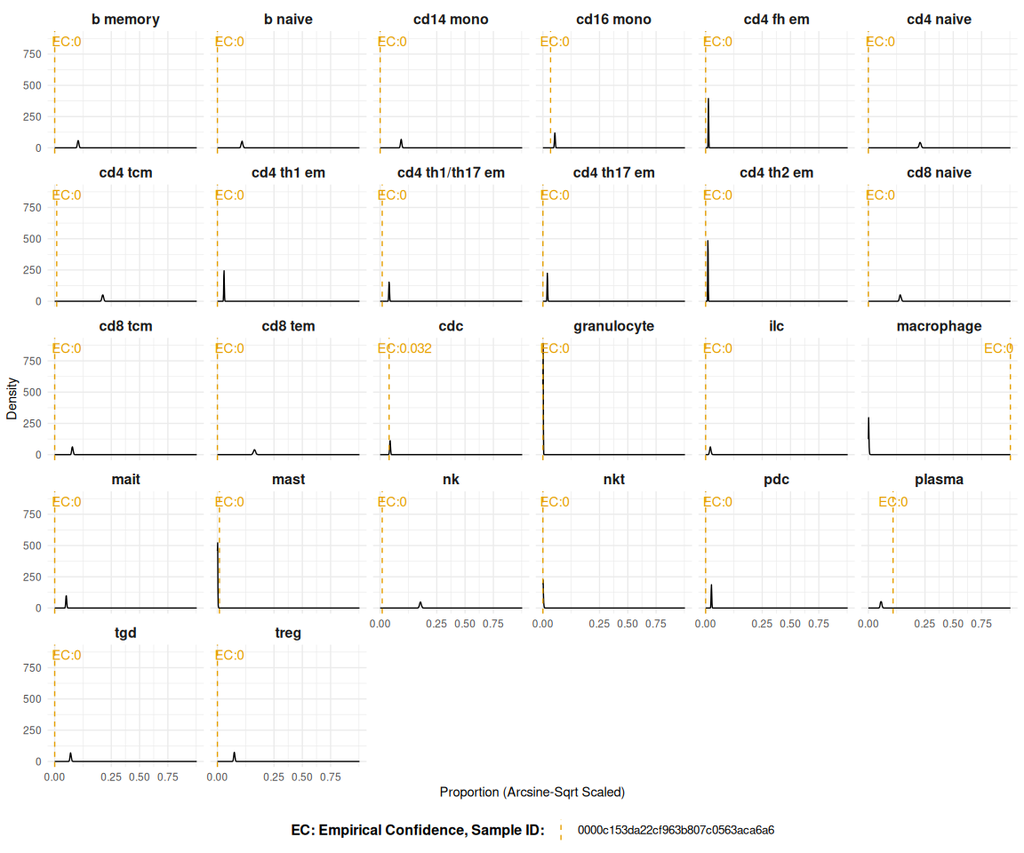

```r
print(result$plot)
```

### **2. Gene Expression Prediction**

The `expr_predict()` function allows predicting gene expression levels for specific cell types and genes based on sample metadata:

```r
# Predict gene expression for a specific cell type and gene
expr_result <- expr_predict(
  cell_type = "cd4 naive",
  gene = "ENSG00000000419",
  age_decade = "7",
  sex = "female",
  disease_groups = "Normal",
  ethnicity_groups = "European",
  assay_groups = "10x Genomics 3",
  tissue_groups = "blood"
)
```

```
#> ℹ Using cached file: /home/a1237163/.cache/R/posteriorHCA/meta/latest.csv
#> ℹ Using cached file: /home/a1237163/.cache/R/posteriorHCA/V1/cd4.naive/genes.csv
#> ℹ Using cached file: /home/a1237163/.cache/R/posteriorHCA/meta/latest.csv
#> ℹ Using cached file: /home/a1237163/.cache/R/posteriorHCA/V1/cd4.naive/ENSG00000000419
#> ℹ Covariate grid has 1 profile (all metadata fixed).
```

#### Inspect Gene Expression Results

**Summary Statistics:**

```r
print(expr_result$summary)
```

[output not shown]

**Density Plot of Predicted Expression:**

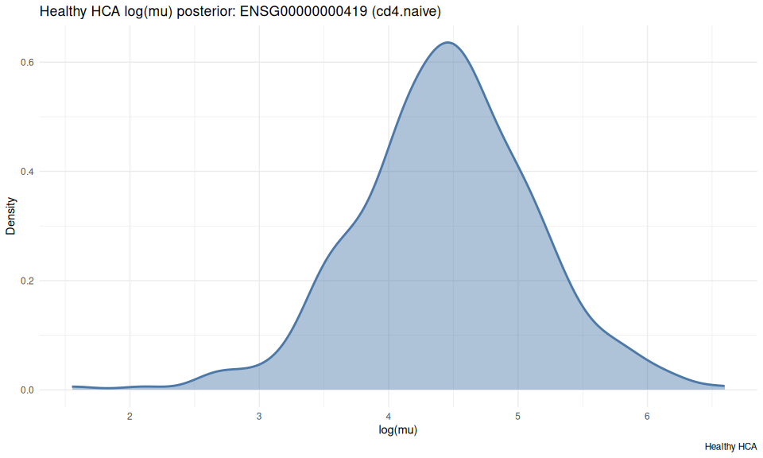

```r
print(expr_result$plot)
```

**Predicted Values:**

```r
head(expr_result$pred)
```

```
#>      value
#> 1 4.958353
#> 2 4.829741
#> 3 4.772091
#> 4 4.446765
#> 5 5.235605
#> 6 3.406768
```

## **Input Arguments and Valid Values**

Both `composition_posterior_test()` / [composition_draws()] and [expr_predict()] accept metadata inputs corresponding to observed sample characteristics. For composition, the default healthy sccomp model uses **sex, age decade, ethnicity, assay, and tissue**. Unknown covariates can be set to `NA` and are marginalised automatically by sccomp. For expression queries, metadata can also be left empty to marginalise over the pre-trained model.

If users choose to specify metadata, it must be consistent with the **Human Cell Atlas (HCA) annotations** to ensure accurate comparisons. Below is a comprehensive list of valid arguments:

- **Cell Types:** “b memory”, “b naive”, “cd14 mono”, “cd16 mono”, “cd4 fh em”, “cd4 naive”, “cd4 tcm”, “cd4 th1 em”, “cd4 th1/th17 em”, “cd4 th17 em”, “cd4 th2 em”, “cd8 naive”, “cd8 tcm”, “cd8 tem”, “cdc”, “granulocyte”, “ilc”, “macrophage”, “mait”, “mast”, “nk”, “nkt”, “pdc”, “plasma”, “tgd”, “treg”
- **Sex:** “female”, “male”, “unknown”
- **Age Decades:** 1, 2, 3, 4, 5, 6, 7, 8, 9, 10
- **Ethnicity Groups:** “African”, “Other/Unknown”, “European”, “East Asian”, “Hispanic/Latin American”, “South Asian”, “Native American & Pacific Islander”
- **Tissue Groups:** “respiratory system”, “blood”, “renal system”, “small intestine”, “nasal, oral, and pharyngeal regions”, “cerebral lobes and cortical areas”, “bone marrow”, “breast”, “cardiovascular system”, “trachea”, “endocrine system”, “liver”, “large intestine”, “lymphatic system”, “prostate”, “sensory-related structures”, “oesophagus”, “spleen”, “brainstem and cerebellar structures”, “stomach”, “female reproductive system”, “thymus”, “adipose tissue”, “integumentary system (skin)”, “digestive system (general)”, “gallbladder”, “pancreas”